# 11_PINN_Limitations_and_Extension_textbook

## 4.2. Causal PINN

A causal PINN keeps one network over the whole domain and changes only how much each time slice is allowed to matter. The change is small enough to be worth deriving rather than asserting.

The construction begins by putting an order on time. Introduce $N_t + 1$ nodes,

$$ 0 = t_0 < t_1 < t_2 < \cdots < t_{N_t} = T , $$

which cut the interval into $N_t$ consecutive slabs,

$$ [t_0, t_1) , \;\; [t_1, t_2) , \;\; \ldots , \;\; [t_{N_t - 1}, t_{N_t}] , $$

the last one closed so that the final time belongs to a slab. Each slab carries a strip of space-time with it,

$$ \Omega_i = \bigl\{ (x, t) \;:\; x \in \Omega , \;\; t_{i-1} \le t < t_i \bigr\} , \qquad i = 1, \ldots, N_t , $$

and the collocation points inherit the partition. Writing $S_i$ for the points that fall in $\Omega_i$ and $N_i = |S_i|$, the full collocation set is the disjoint union of the $S_i$, so that $\sum_i N_i = N$. Define the residual loss restricted to one slab,

$$ L_i = \frac{1}{N_i} \sum_{(x_j, t_j) \,\in\, S_i} r_\theta(x_j, t_j)^2 . $$

In Section 4.1 and in the lab below the collocation points are drawn on a grid, $N_t$ time levels with $N_x$ points each. Each slab then contains exactly one level, which we continue to write $t_i$, so that $N_i = N_x$ and the definition reduces to the average over that level,

$$ L_i = \frac{1}{N_x} \sum_{j=1}^{N_x} r_\theta(x_j, t_i)^2 . $$

Nothing that follows depends on which of the two is used. The slabs matter only because they are ordered, and the same partition reappears in Section 4.4, where the windows of time marching are these slabs trained one at a time rather than weighted.

These slab losses are not a new object; they are the old loss taken apart. Collecting the sum over all collocation points slab by slab,

$$ \mathcal{L}_{\mathrm{PDE}} = \frac{1}{N} \sum_{j=1}^{N} r_\theta(x_j, t_j)^2 = \sum_{i=1}^{N_t} \frac{N_i}{N}\, L_i , $$

and when the slabs are sampled uniformly, so that $N_i = N / N_t$,

$$ \mathcal{L}_{\mathrm{PDE}} = \frac{1}{N_t} \sum_{i=1}^{N_t} L_i . $$

Nothing has happened yet; this is the same number written differently. But in this form the objection of Section 4.1 can be stated exactly. The loss is already a sum over time slabs, and every slab enters with the same coefficient $1/N_t$. The coefficient multiplying the last slab does not depend on how well the first has been fitted. That constant, identical for every $i$, is the whole of the problem.

Causal training replaces it by a coefficient that does depend on the earlier slices,

$$ \mathcal{L}_{\mathrm{PDE}}^{\mathrm{causal}} = \frac{1}{N_t}\sum_{i=1}^{N_t} w_i\,L_i , \qquad w_i = \exp\Bigl(-\epsilon\sum_{k<i} L_k\Bigr) , $$

with a single new parameter $\epsilon > 0$. The sum in the exponent runs over the slices strictly before $i$, so it is the accumulated residual error upstream in time. Written out, the first few weights are

$$ w_1 = e^0 = 1 , \qquad w_2 = e^{-\epsilon L_1} , \qquad w_3 = e^{-\epsilon(L_1 + L_2)} , \qquad w_4 = e^{-\epsilon(L_1 + L_2 + L_3)} , $$

and in general each weight is the previous one multiplied by one more factor,

$$ w_{i+1} = w_i\,e^{-\epsilon L_i} , \qquad e^{-\epsilon L_i} \in (0, 1] . $$

Three properties follow from this recursion alone. The first slice has an empty sum in its exponent, so $w_1 = 1$ for the whole of training: the slice next to the initial condition is never gated. The weights are non-increasing in time,

$$ 1 = w_1 \ge w_2 \ge \cdots \ge w_{N_t} > 0 , $$

a staircase descending into the future. And a weight is close to one only when every slice before it has small loss, since one large $L_k$ contributes a small factor that suppresses all the weights after it.

What the weights do to training is seen in the gradient. Since they are held fixed when the derivative is taken,

$$ \nabla_\theta\,\mathcal{L}_{\mathrm{PDE}}^{\mathrm{causal}} = \frac{1}{N_t}\sum_{i=1}^{N_t} w_i\,\nabla_\theta L_i , $$

so $w_i$ is how loudly slice $i$ speaks in a parameter update. At the first iteration $L_1$ is large, $w_2$ and everything after it are near zero, and the update is driven by the first slice alone: the network is in effect solving the equation next to the initial condition that anchors it. As $L_1$ falls, $w_2$ rises towards one and the second slice begins to contribute; as $L_2$ falls in turn, the third follows. Training proceeds from left to right in time, not because the collocation points are ordered but because the loss is: the later residuals are present at every iteration, and they are ignored until the earlier ones have been dealt with.

The parameter $\epsilon$ sets how strictly the order is enforced. For $\epsilon \to 0$ every weight is one and the ordinary loss is recovered; for large $\epsilon$ even a small early loss suppresses everything after it. It has a scale rather than a universal value, since $L_k$ carries the units of the residual squared and a value tuned for one equation does not transfer to another whose residual is measured differently.

Two details of the implementation matter. The accumulated losses inside the exponential are detached from the graph, so that the weights act as a schedule and are not themselves optimized; otherwise the optimizer would discover that $\sum_i w_i L_i$ can be reduced by shrinking the weights rather than the residuals. And the weights are recomputed at every iteration from the current residuals, so that the active region moves forward on its own as the solution improves. Nothing else changes: no new equation, no extra network, no partition of the domain.

The mechanism in miniature, for six time slices. In the left panel all six losses are equal to $1$ and the weights are shown for three values of $\epsilon$; in the middle panel the first loss has dropped to $0.2$; in the right panel the first two have.

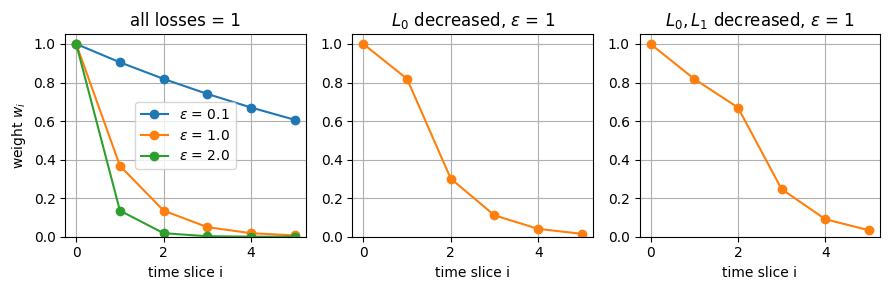

```python
def causal_weights(L, eps):
    L = np.array(L)
    return np.exp(-eps*(np.cumsum(L) - L))

L1 = [1, 1, 1, 1, 1, 1]
L2 = [0.2, 1, 1, 1, 1, 1]
L3 = [0.2, 0.2, 1, 1, 1, 1]

plt.figure(figsize = (9, 3))

plt.subplot(1, 3, 1)
for eps in [0.1, 1.0, 2.0]:
    plt.plot(causal_weights(L1, eps), 'o-', label = r'$\epsilon$ = %.1f' % eps)
plt.title('all losses = 1')
plt.xlabel('time slice i')
plt.ylabel(r'weight $w_i$')
plt.ylim(0, 1.05)
plt.legend()
plt.grid(True)

plt.subplot(1, 3, 2)
plt.plot(causal_weights(L2, 1.0), 'o-', color = 'C1')
plt.title(r'$L_0$ decreased, $\epsilon$ = 1')
plt.xlabel('time slice i')
plt.ylim(0, 1.05)
plt.grid(True)

plt.subplot(1, 3, 3)
plt.plot(causal_weights(L3, 1.0), 'o-', color = 'C1')
plt.title(r'$L_0, L_1$ decreased, $\epsilon$ = 1')
plt.xlabel('time slice i')
plt.ylim(0, 1.05)
plt.grid(True)

plt.tight_layout()
plt.show()
```

In the left panel the weights fall off geometrically with the slice index, slowly for $\epsilon = 0.1$ and steeply for $\epsilon = 2$; at the start of training only the first slice or two are active. When the first loss drops, the weights of all later slices rise together, because the sum inside the exponential has shrunk for every one of them; when the second drops as well, the active front moves one slice further. The region in which the equation is actually enforced advances in time as the solution behind it converges, which is the behaviour of a time-stepping scheme obtained from a single loss.

Because the weights descend, the smallest of them is always the last,

$$ \min_i w_i = w_{N_t} , $$

and that single number says whether training ever finished. If $w_{N_t}$ has risen close to one by the end of the run, every gate has opened and the equation has been enforced over the whole interval. If it is still small, the active front never reached the end: the late slices were never fitted, and the prediction there should not be trusted however small the reported total loss is, because the total is small precisely in virtue of having weighted those slices out of it. The quantity that gates the training doubles as the diagnostic that validates it, and is worth recording alongside the loss. It also gives a practical rule for $\epsilon$: take the largest value for which $w_{N_t}$ still reaches one within the iteration budget.

## 4.3. Lab: 1D Allen–Cahn Equation

The causal model is the naive model of Section 4.1 with one change, the weighting of the residual in time. Same network, same Fourier features, same collocation grid, same optimizer and learning-rate schedule, same initial-condition weight and the same $150000$ iterations. Whatever differs in the result is due to the order in which the residuals were allowed to act.

### 4.3.1. Causal Training

The only change to the training loop is the causal weighting of the residual, with $\epsilon = 100$, a large value because the slice losses here are small numbers. The smallest weight is printed alongside the losses as training proceeds, so that the advancing front can be watched.

```python
# # Training takes a long time. The pre-trained model is loaded in the cells below.

# causal_net = new_pinn()
# optimizer = torch.optim.Adam(causal_net.parameters(), lr = 1e-3)
# scheduler = torch.optim.lr_scheduler.ExponentialLR(optimizer, gamma = 0.9**(1/5000))

# eps = 100.0
# n_iter = 150000

# for it in range(1, n_iter + 1):
#     r = residual(causal_net, x_pde, t_pde)
#     L = torch.mean(r.reshape(100, 256)**2, dim = 1)                 # one loss per time slice
#     w = torch.exp(-eps*(torch.cumsum(L, 0) - L)).detach()           # causal weights
#     loss_pde = torch.mean(w*L)
#     loss_ic = torch.mean((causal_net(features(x_ic, t_ic)) - u_ic)**2)
#     loss = loss_pde + 100*loss_ic

#     optimizer.zero_grad()
#     loss.backward()
#     optimizer.step()
#     scheduler.step()

#     if it == 1 or it % 10000 == 0:
#         print('Causal | %6d | Total %.3e | PDE %.3e | IC %.3e | W_min %.2e' % (it, loss.item(), loss_pde.item(), loss_ic.item(), w.min().item()))
```

```python
# torch.save(causal_net, 'allen_cahn_causal.pt')
```

The trained network is downloaded and loaded instead.

[allen_cahn_causal.pt](https://drive.google.com/file/d/1qT3Fehd64l0dwP5wzJWB7yEIyLXNTJl3/view?usp=sharing)

```python
!gdown 1qT3Fehd64l0dwP5wzJWB7yEIyLXNTJl3 -O allen_cahn_causal.pt
```

```
Downloading...
From: https://drive.google.com/uc?id=1qT3Fehd64l0dwP5wzJWB7yEIyLXNTJl3
To: /content/allen_cahn_causal.pt
100% 217k/217k [00:00<00:00, 89.9MB/s]
```

```python
causal_net = torch.load('allen_cahn_causal.pt', map_location = device, weights_only = False)
```

### 4.3.2. Results

The two predictions side by side with the reference, their error maps, and the time-wise error.

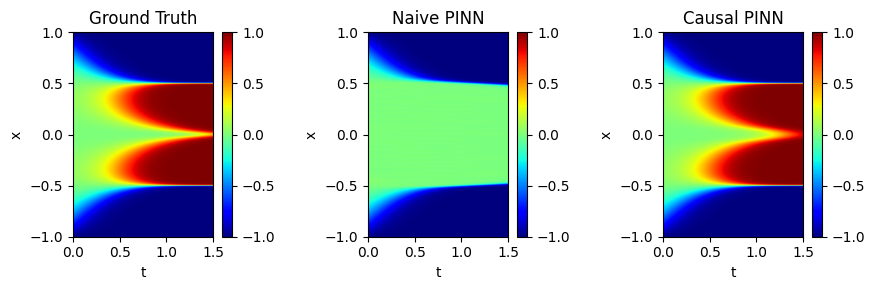

```python
u_causal = predict(causal_net)
error_causal = np.abs(u_causal - u_ref)

plt.figure(figsize = (9, 3))

plt.subplot(1, 3, 1)
plt.imshow(u_ref.T, extent = [0, 1.5, -1, 1], origin = 'lower', aspect = 'auto', cmap = 'jet', vmin = -1, vmax = 1)
plt.colorbar()
plt.title('Ground Truth')
plt.xlabel('t')
plt.ylabel('x')

plt.subplot(1, 3, 2)
plt.imshow(u_naive.T, extent = [0, 1.5, -1, 1], origin = 'lower', aspect = 'auto', cmap = 'jet', vmin = -1, vmax = 1)
plt.colorbar()
plt.title('Naive PINN')
plt.xlabel('t')
plt.ylabel('x')

plt.subplot(1, 3, 3)
plt.imshow(u_causal.T, extent = [0, 1.5, -1, 1], origin = 'lower', aspect = 'auto', cmap = 'jet', vmin = -1, vmax = 1)
plt.colorbar()
plt.title('Causal PINN')
plt.xlabel('t')
plt.ylabel('x')

plt.tight_layout()
plt.show()
```

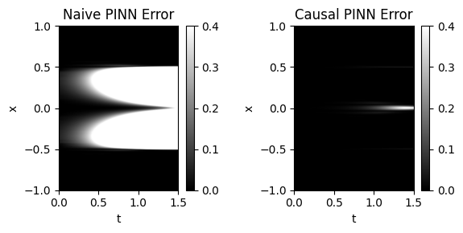

```python
plt.figure(figsize = (6, 3))

plt.subplot(1, 2, 1)
plt.imshow(error_naive.T, extent = [0, 1.5, -1, 1], origin = 'lower', aspect = 'auto', cmap = 'gray', vmin = 0, vmax = 0.4)
plt.colorbar()
plt.title('Naive PINN Error')
plt.xlabel('t')
plt.ylabel('x')

plt.subplot(1, 2, 2)
plt.imshow(error_causal.T, extent = [0, 1.5, -1, 1], origin = 'lower', aspect = 'auto', cmap = 'gray', vmin = 0, vmax = 0.4)
plt.colorbar()
plt.title('Causal PINN Error')
plt.xlabel('t')
plt.ylabel('x')

plt.tight_layout()
plt.show()
```

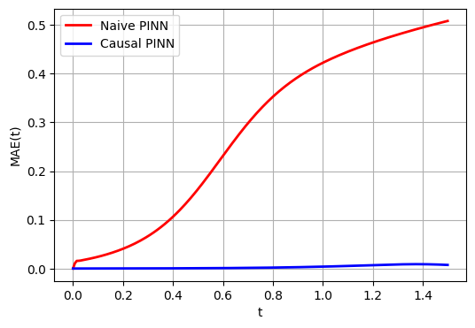

```python
plt.figure(figsize = (6, 4))
plt.plot(t_ref, np.mean(error_naive, axis = 1), 'r', linewidth = 2, label = 'Naive PINN')
plt.plot(t_ref, np.mean(error_causal, axis = 1), 'b', linewidth = 2, label = 'Causal PINN')
plt.xlabel('t')
plt.ylabel('MAE(t)')
plt.legend()
plt.grid(True)
plt.show()
```

The causal prediction is the reference solution: the bump grows into the two plateaus, the transition layers sharpen at the right times, and the error map is dark over the whole rectangle except for faint lines along the transitions, where a small misplacement of a steep front produces a visible error. Its $\mathrm{MAE}(t)$ stays near zero across the interval, where the naive model's grew steadily from the start. Both runs end with a loss of the same small size; the difference between the models is not in how small the loss became but in which solution of the equation it was small on.

### 4.3.3. What the Lab Showed

The naive and causal models solve the same equation with the same initial condition, the same network and the same budget; what the causal model changes is when each residual is permitted to influence the parameters. That a better late-time prediction follows is evidence that order matters in the training of a transient PINN, not evidence about the equation or the boundary treatment, which were untouched. The lesson is that a trajectory has to be built from its initial state forward, and that a loss which does not say so will be minimized in whatever order is cheapest.

## 4.4. Time Marching

Causal weighting keeps one network over the whole interval and arranges the loss so that the network learns the interval in order. Time marching is the more literal approach: it changes the problem rather than the loss, by cutting the interval into windows

$$ [t_0, t_1],\ [t_1, t_2],\ \ldots,\ [t_{M-1}, t_M] $$

and solving them one after another. The first window is an ordinary PINN problem on a short interval, with the true initial condition. When it has converged, its solution at $t_1$ becomes the initial condition of the second window,

$$ u_k(x, t_k) \;\longrightarrow\; u_{k+1}(x, t_k) , $$

imposed by a penalty of the usual form,

$$ \mathcal{L}_{\mathrm{interface}} = \frac{1}{N_x}\sum_i\bigl[u_{k+1}(x_i, t_k) - u_k(x_i, t_k)\bigr]^2 , $$

and the second window is trained; and so on to the end. The network of each window is usually initialized from the trained network of the one before, so that both the state and a good starting point for the weights are passed forward.

What this buys is a short horizon. While the first window is being trained, the far future is not in the problem at all, so the optimizer cannot spend effort on it and cannot be led astray by it; the trajectory is built forward in the same direction as the physics, one window at a time. What it costs is sequential dependence. A later window cannot start until the earlier one is done, so the stages cannot be run in parallel, and an error at an interface is handed to every window after it. The window length sets the trade-off: short windows keep each problem easy but multiply the number of stages and interfaces, long windows do the opposite, and in the limit of one window the method is the naive PINN again.

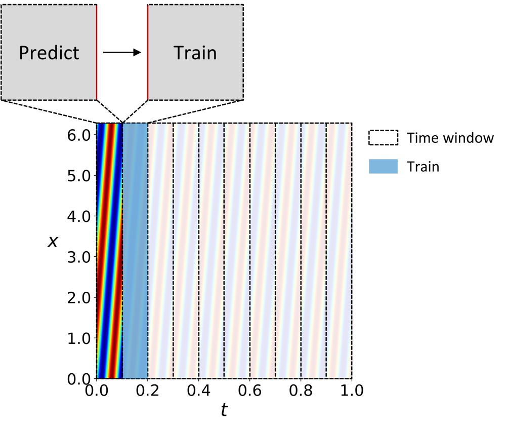

**Time marching.** The interval is cut into windows. The shaded window is the one being trained; the windows to its right are not in the problem yet. When a window converges, its solution at the right edge is predicted and handed to the next window as an initial condition.

The figure shows the arrangement. The interval is divided into windows, the one being trained is shaded, and the ones before it have already been solved and frozen; the state at the right edge of a solved window is predicted and handed to the next as its initial condition. Causal weighting and time marching impose the same order at different levels, one inside a single objective and the other across a sequence of problems, and the difference will be visible in the next demonstration: in the time-marching prediction the future is simply absent until its window has been trained.

## 4.5. Lab: 1D Convection Equation

### 4.5.1. Problem Setup

Time marching is demonstrated on the linear convection equation

$$ \frac{\partial u}{\partial t} + \beta\,\frac{\partial u}{\partial x} = 0 , \qquad x \in [0, 2\pi], \quad t \in [0, 1] , $$

with the periodic boundary condition $u(0, t) = u(2\pi, t)$ and the initial condition $u(x, 0) = \sin x$. The exact solution is

$$ u(x, t) = \sin(x - \beta t) : $$

the initial profile travels to the right at speed $\beta$ without changing shape. For $\beta = 1$ it moves a sixth of the way around the periodic domain in the unit interval. For $\beta = 80$ it goes around nearly thirteen times, and the solution in the $(t, x)$ plane is a dense set of diagonal stripes. The equation is as simple as a PDE can be; the only difficulty is that information has to be carried a long way from the initial condition, which is exactly the situation in which a full-domain PINN loses its way.

The exact solution in the $(t, x)$ plane for the two speeds.

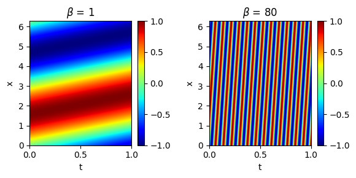

```python
beta = 80.0
T_ex, X_ex = np.meshgrid(np.linspace(0, 1, 300), np.linspace(0, 2*np.pi, 300), indexing = 'ij')

plt.figure(figsize = (6, 3))

plt.subplot(1, 2, 1)
plt.imshow(np.sin(X_ex - 1.0*T_ex).T, extent = [0, 1, 0, 2*np.pi], origin = 'lower', aspect = 'auto', cmap = 'jet', vmin = -1, vmax = 1)
plt.colorbar()
plt.title(r'$\beta$ = 1')
plt.xlabel('t')
plt.ylabel('x')

plt.subplot(1, 2, 2)
plt.imshow(np.sin(X_ex - beta*T_ex).T, extent = [0, 1, 0, 2*np.pi], origin = 'lower', aspect = 'auto', cmap = 'jet', vmin = -1, vmax = 1)
plt.colorbar()
plt.title(r'$\beta$ = 80')
plt.xlabel('t')
plt.ylabel('x')

plt.tight_layout()
plt.show()
```

```python
import numpy as np
import matplotlib.pyplot as plt
from matplotlib.animation import FuncAnimation
from IPython.display import HTML

beta = 80.0
x = np.linspace(0, 2*np.pi, 300)
t_steps = np.linspace(0, 1, 100)

fig, ax = plt.subplots(figsize=(6, 4))
line, = ax.plot(x, np.sin(x - beta * 0), color='gray', lw=2)

ax.set_xlim(0, 2*np.pi)
ax.set_ylim(-1.1, 1.1)
ax.set_title(r'1D Wave Propagation ($\beta = 80$)')
ax.set_xlabel('x')
ax.set_ylabel('u(x, t)')
ax.grid(True)

def update(frame):
    t = t_steps[frame]
    y = np.sin(x - beta * t)
    line.set_ydata(y)
    return [line]

ani = FuncAnimation(fig, update, frames=len(t_steps), interval=50, blit=True)

plt.close()
HTML(ani.to_jshtml())
```

[figure not shown]

### 4.5.2. Naive and Time-Marching Formulations

Both models use the same network and the same residual $r_\theta = \dfrac{\partial u_\theta}{\partial t} + \beta\,\dfrac{\partial u_\theta}{\partial x}$. For the naive model the loss is

$$ \mathcal{L} = \mathcal{L}_{\mathrm{PDE}} + \mathcal{L}_{\mathrm{IC}} + \mathcal{L}_{\mathrm{BC}} , $$

with the initial condition $u_\theta(x, 0) = \sin x$ and the periodic condition $u_\theta(0, t) = u_\theta(2\pi, t)$ both as penalties, and the residual over the whole rectangle. For time marching the same three terms are used inside each window, with the initial-condition target replaced, from the second window on, by the previous window's prediction at the interface.

```python
def features_conv(x, t):
    return torch.cat([x/np.pi - 1, 2*t - 1], dim = 1)        # inputs scaled to [-1, 1]

def new_conv_pinn():
    net = nn.Sequential(nn.Linear(2, 64), nn.Tanh(),
                        nn.Linear(64, 64), nn.Tanh(),
                        nn.Linear(64, 64), nn.Tanh(),
                        nn.Linear(64, 64), nn.Tanh(),
                        nn.Linear(64, 1))
    return net.to(device)

def pde_loss(net, x, t):
    u = net(features_conv(x, t))
    r = derivative(u, t) + beta*derivative(u, x)
    return torch.mean(r**2)

def bc_loss(net, t):
    x0 = torch.zeros_like(t)
    x1 = torch.full_like(t, 2*np.pi)
    return torch.mean((net(features_conv(x0, t)) - net(features_conv(x1, t)))**2)

x_ic = torch.linspace(0, 2*np.pi, 128).reshape(-1, 1).to(device)
t_ic = torch.zeros_like(x_ic)
u_ic = torch.sin(x_ic)

x_1d = torch.linspace(0, 2*np.pi, 66)[1:-1]
t_1d = torch.linspace(0, 1, 257)[1:]
T_pde, X_pde = torch.meshgrid(t_1d, x_1d, indexing = 'ij')
x_pde = X_pde.reshape(-1, 1).to(device).requires_grad_(True)
t_pde = T_pde.reshape(-1, 1).to(device).requires_grad_(True)
t_bc = torch.linspace(0, 1, 128).reshape(-1, 1).to(device)

t_eval_1d = np.linspace(0, 1, 300)
x_eval_1d = np.linspace(0, 2*np.pi, 300)
T_eval, X_eval = np.meshgrid(t_eval_1d, x_eval_1d, indexing = 'ij')
x_eval = torch.tensor(X_eval.reshape(-1, 1), dtype = torch.float32).to(device)
t_eval = torch.tensor(T_eval.reshape(-1, 1), dtype = torch.float32).to(device)
u_exact = np.sin(X_eval - beta*T_eval)

def predict_conv(net):
    return net(features_conv(x_eval, t_eval)).detach().cpu().numpy().reshape(300, 300)
```

### 4.5.3. Naive PINN

The naive model is trained on the whole rectangle at once, with the iteration budget that the time-marching run will share.

```python
# # Training takes a long time. The pre-trained model is loaded in the cells below.

# naive_net = new_conv_pinn()
# optimizer = torch.optim.Adam(naive_net.parameters(), lr = 1e-4)

# n_iter = 200000

# for it in range(1, n_iter + 1):
#     loss_pde = pde_loss(naive_net, x_pde, t_pde)
#     loss_ic = torch.mean((naive_net(features_conv(x_ic, t_ic)) - u_ic)**2)
#     loss_bc = bc_loss(naive_net, t_bc)
#     loss = loss_pde + loss_ic + loss_bc

#     optimizer.zero_grad()
#     loss.backward()
#     optimizer.step()

#     if it == 1 or it % 20000 == 0:
#         print('Naive | %6d | Total %.3e | PDE %.3e | IC %.3e | BC %.3e' % (it, loss.item(), loss_pde.item(), loss_ic.item(), loss_bc.item()))
```

```python
# torch.save(naive_net, 'convection_naive.pt')
```

The trained network is downloaded and loaded instead.

[convection_naive.pt](https://drive.google.com/file/d/11w-9bDpi1JLfzy7e6lwJgq0aiZilODl5/view?usp=drive_link)

```python
!gdown 11w-9bDpi1JLfzy7e6lwJgq0aiZilODl5 -O convection_naive.pt
```

```
Downloading...
From: https://drive.google.com/uc?id=11w-9bDpi1JLfzy7e6lwJgq0aiZilODl5
To: /content/convection_naive.pt
100% 57.4k/57.4k [00:00<00:00, 61.8MB/s]
```

```python
naive_net = torch.load('convection_naive.pt', map_location = device, weights_only = False)
```

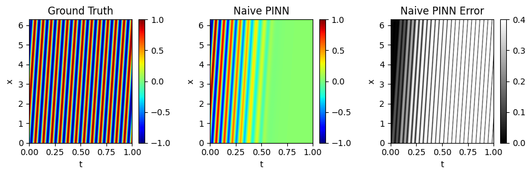

```python
u_naive = predict_conv(naive_net)
error_naive = np.abs(u_naive - u_exact)

plt.figure(figsize = (9, 3))

plt.subplot(1, 3, 1)
plt.imshow(u_exact.T, extent = [0, 1, 0, 2*np.pi], origin = 'lower', aspect = 'auto', cmap = 'jet', vmin = -1, vmax = 1)
plt.colorbar()
plt.title('Ground Truth')
plt.xlabel('t')
plt.ylabel('x')

plt.subplot(1, 3, 2)
plt.imshow(u_naive.T, extent = [0, 1, 0, 2*np.pi], origin = 'lower', aspect = 'auto', cmap = 'jet', vmin = -1, vmax = 1)
plt.colorbar()
plt.title('Naive PINN')
plt.xlabel('t')
plt.ylabel('x')

plt.subplot(1, 3, 3)
plt.imshow(error_naive.T, extent = [0, 1, 0, 2*np.pi], origin = 'lower', aspect = 'auto', cmap = 'gray', vmin = 0, vmax = 0.4)
plt.colorbar()
plt.title('Naive PINN Error')
plt.xlabel('t')
plt.ylabel('x')

plt.tight_layout()
plt.show()
```

### 4.5.4. Time Marching

The interval is divided into ten windows of equal length, each trained for a tenth of the naive run's budget, so that the two runs cost the same. The first window starts from $\sin x$; each later window starts from the previous network's prediction at the shared time, computed once and held fixed, and its network is initialized from the previous window's weights.

```python
# # Training takes a long time. The pre-trained model is loaded in the cells below.

# n_windows = 10
# n_iter = 200000
# tm_nets = []
# it = 0

# net = new_conv_pinn()

# for w in range(n_windows):
#     t_start = w/n_windows
#     t_end = (w + 1)/n_windows

#     if w > 0:
#         u_start = net(features_conv(x_ic, torch.full_like(x_ic, t_start))).detach()    # end state of the previous window
#         new_net = new_conv_pinn()
#         new_net.load_state_dict(net.state_dict())
#         net = new_net
#     else:
#         u_start = u_ic

#     optimizer = torch.optim.Adam(net.parameters(), lr = 1e-4)

#     T_w, X_w = torch.meshgrid(torch.linspace(t_start, t_end, 257)[1:], x_1d, indexing = 'ij')
#     x_w = X_w.reshape(-1, 1).to(device).requires_grad_(True)
#     t_w = T_w.reshape(-1, 1).to(device).requires_grad_(True)
#     t_bc_w = torch.linspace(t_start, t_end, 128).reshape(-1, 1).to(device)

#     for _ in range(n_iter//n_windows):
#         it += 1
#         loss_pde = pde_loss(net, x_w, t_w)
#         loss_ic = torch.mean((net(features_conv(x_ic, torch.full_like(x_ic, t_start))) - u_start)**2)
#         loss_bc = bc_loss(net, t_bc_w)
#         loss = loss_pde + loss_ic + loss_bc

#         optimizer.zero_grad()
#         loss.backward()
#         optimizer.step()

#         if it == 1 or it % 20000 == 0:
#             print('Time marching | %6d | Window %2d | Total %.3e' % (it, w + 1, loss.item()))

#     tm_nets.append(net)
```

```python
# torch.save(tm_nets, 'convection_time_marching.pt')
```

One network per window, stored together in one file.

[convection_time_marching.pt](https://drive.google.com/file/d/1Kk5iJKANsDRT1i5ESgyDbCRqzGAhllCi/view?usp=drive_link)

```python
!gdown 1Kk5iJKANsDRT1i5ESgyDbCRqzGAhllCi -O convection_time_marching.pt
```

```
Downloading...
From: https://drive.google.com/uc?id=1Kk5iJKANsDRT1i5ESgyDbCRqzGAhllCi
To: /content/convection_time_marching.pt
100% 563k/563k [00:00<00:00, 123MB/s]
```

```python
n_windows = 10
tm_nets = torch.load('convection_time_marching.pt', map_location = device, weights_only = False)
```

### 4.5.5. Results

The time-marching prediction is assembled window by window, each network supplying the times of its own window.

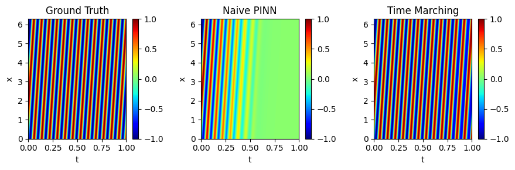

```python
u_naive = predict_conv(naive_net)

u_tm = np.zeros((300, 300))
for w in range(n_windows):
    u_w = predict_conv(tm_nets[w])
    rows = (t_eval_1d >= w/n_windows) & (t_eval_1d <= (w + 1)/n_windows)
    u_tm[rows] = u_w[rows]

error_naive = np.abs(u_naive - u_exact)
error_tm = np.abs(u_tm - u_exact)

plt.figure(figsize = (9, 3))

plt.subplot(1, 3, 1)
plt.imshow(u_exact.T, extent = [0, 1, 0, 2*np.pi], origin = 'lower', aspect = 'auto', cmap = 'jet', vmin = -1, vmax = 1)
plt.colorbar()
plt.title('Ground Truth')
plt.xlabel('t')
plt.ylabel('x')

plt.subplot(1, 3, 2)
plt.imshow(u_naive.T, extent = [0, 1, 0, 2*np.pi], origin = 'lower', aspect = 'auto', cmap = 'jet', vmin = -1, vmax = 1)
plt.colorbar()
plt.title('Naive PINN')
plt.xlabel('t')
plt.ylabel('x')

plt.subplot(1, 3, 3)
plt.imshow(u_tm.T, extent = [0, 1, 0, 2*np.pi], origin = 'lower', aspect = 'auto', cmap = 'jet', vmin = -1, vmax = 1)
plt.colorbar()
plt.title('Time Marching')
plt.xlabel('t')
plt.ylabel('x')

plt.tight_layout()
plt.show()
```

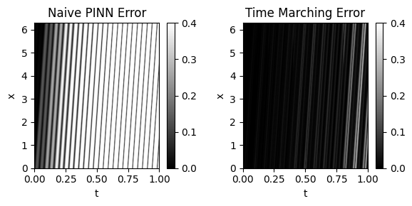

```python
plt.figure(figsize = (6, 3))

plt.subplot(1, 2, 1)
plt.imshow(error_naive.T, extent = [0, 1, 0, 2*np.pi], origin = 'lower', aspect = 'auto', cmap = 'gray', vmin = 0, vmax = 0.4)
plt.colorbar()
plt.title('Naive PINN Error')
plt.xlabel('t')
plt.ylabel('x')

plt.subplot(1, 2, 2)
plt.imshow(error_tm.T, extent = [0, 1, 0, 2*np.pi], origin = 'lower', aspect = 'auto', cmap = 'gray', vmin = 0, vmax = 0.4)
plt.colorbar()
plt.title('Time Marching Error')
plt.xlabel('t')
plt.ylabel('x')

plt.tight_layout()
plt.show()
```

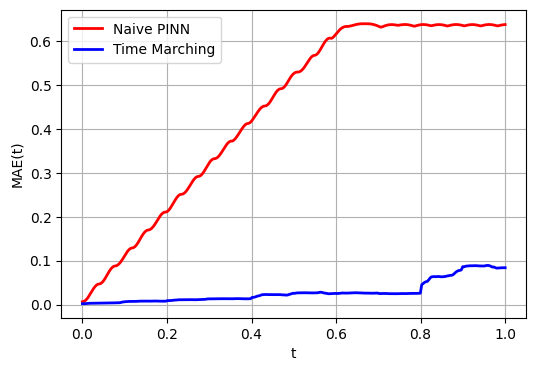

```python
plt.figure(figsize = (6, 4))
plt.plot(t_eval_1d, np.mean(error_naive, axis = 1), 'r', linewidth = 2, label = 'Naive PINN')
plt.plot(t_eval_1d, np.mean(error_tm, axis = 1), 'b', linewidth = 2, label = 'Time Marching')
plt.xlabel('t')
plt.ylabel('MAE(t)')
plt.legend()
plt.grid(True)
plt.show()
```

The naive prediction reproduces the stripes for about the first third of the interval, then loses amplitude and finally collapses to a flat field near zero, which is once again a zero-residual solution of the equation that the initial condition does not permit. Its error map is dark on the left and bright on the right, and $\mathrm{MAE}(t)$ rises steadily from zero before saturating at the level of predicting nothing at all. The time-marching prediction has the stripes all the way across, with an error map that is nearly uniformly dark and a $\mathrm{MAE}(t)$ that stays small to $t = 1$.

### 4.5.6. What the Lab Showed

Convection at $\beta = 80$ is an easy equation and a hard transport problem: the solution at $t = 1$ is the initial condition carried thirteen times around the domain, and a network asked to fit the whole rectangle at once gives up on the far end and settles for a trivial solution there. Time marching never asks for the far end. Each window is a short problem with its initial condition one window away, the state is handed forward explicitly, and the stripes are carried across the interval the way the equation carries them, from left to right.

## 4.6. A Second Problem with Time: Scale

Section 4.1 showed one way in which time can defeat a PINN. The optimizer worked on the late times before the early times were right, and it settled on a trajectory that the initial condition does not produce. That was a problem of *order*, and causal weighting fixed it by making the network learn the early times first.

This section is about a second problem, and it is worth keeping the two apart because they look alike from the outside: in both, the prediction is bad at late times. Here, however, the order of training is fine, the collocation points are fine, and the trajectory is the right one. The problem is *size*. A diffusing solution shrinks as time goes on, and by the end of the interval it can be a hundred times smaller than at the start. The loss is built from squared residuals, and whatever is a hundred times smaller becomes ten thousand times smaller once it is squared. The late times are still in the loss, but they have become too small to be heard.

### 4.6.1. A Decaying Solution Weights Its Own Loss

Start with a picture. Suppose the network is wrong by ten percent at every time. At $t = 0$ the solution has size $1$, so the error is $0.1$ and its square is $0.01$. At $t = T$ the solution has shrunk to $0.01$, so the same ten-percent error is $0.001$ and its square is $10^{-6}$. The optimizer sees the second mistake as ten thousand times less important than the first, even though the two are equally bad in relative terms. Nobody asked for the late times to be discounted; the decay of the solution did it.

Now the same statement made exact. Solutions of the heat equation with fixed ends decay like $e^{-\lambda t}$. So write the solution as the known decay times a field that does not decay,

$$ \begin{align*} \frac{u(x, t)}{e^{-\lambda t}} &= v(x, t)\\\\ u(x, t) &= e^{-\lambda t}\, v(x, t) \end{align*} $$

Here $v$ is nothing more than $u$ magnified by $e^{\lambda t}$, enough to undo the decay, so that $v$ stays of size one over the whole interval. Substitute into the heat equation. By the product rule,

$$ u_t = e^{-\lambda t}\bigl(v_t - \lambda v\bigr) , \qquad u_{xx} = e^{-\lambda t} v_{xx} $$

so the residual of the original equation is a shrinking factor times a residual of $v$:

$$ \boxed{\;r_u = u_t - \alpha u_{xx} = e^{-\lambda t}\underbrace{\bigl(v_t - \alpha v_{xx} - \lambda v\bigr)}_{r_v}\;} $$

Square it and average over collocation points spread uniformly in time, and you have the loss the PINN actually minimizes:

$$ \mathcal{L} = \frac{1}{N_f}\sum_{j=1}^{N_f} r_u(x_j, t_j)^2 = \frac{1}{N_f}\sum_{j=1}^{N_f} e^{-2\lambda t_j}\; r_v(x_j, t_j)^2 $$

Read the right-hand side as a weighted loss on $v$: the point at time $t_j$ carries the weight $e^{-2\lambda t_j}$. This is the ten-thousand-to-one of the picture above, now with its exact value. The plain loss on $u$ was a weighted loss all along, and the weights were chosen by the decay, not by us.

How bad is it? For the heat equation on the unit interval with fixed ends, $\lambda = \alpha\pi^2 \approx 9.9$ when $\alpha = 1$. The table gives, for three interval lengths, how far the solution has decayed by $t = T$, how much weight the loss gives to $t = T$ compared with $t = 0$, and how early half of the whole loss has already been spent.

| $T$ | $u(T)/u(0)$ | weight at $t = T$ relative to $t = 0$ | half of the loss accumulates below |
| --- | --- | --- | --- |
| $0.1$ | $0.37$ | $1.4\times10^{-1}$ | $t = 0.029$, the first $28\%$ |
| $0.3$ | $0.052$ | $2.7\times10^{-3}$ | $t = 0.035$, the first $12\%$ |
| $0.5$ | $0.0072$ | $5.2\times10^{-5}$ | $t = 0.035$, the first $7\%$ |

Take the last row. At $T = 0.5$ half of the objective is decided in the first seven percent of the interval. Over the remaining ninety-three percent of the time axis the optimizer is almost free to do as it likes: the network can be wrong there by more than the solution is large, and the loss barely notices.

> **Remark (causal weighting does not fix this).** The causal weights of Section 4.2 make a late slice small only *while the earlier slices are still badly fitted*. Once those are learned, every weight returns to one and the loss is the plain average again, with the $e^{-2\lambda t}$ imbalance untouched. Causal weighting decides *when* a time is allowed to count; this section is about *how much* it counts once it does. Two different problems, two different remedies.

### 4.6.2. Dividing Out the Known Decay

The identity also tells us what to do. If training on $u$ is secretly training on $v$ with bad weights, then train on $v$ directly: let the network represent the magnified field $v$, and recover $u = e^{-\lambda t}v$ afterwards. Think of it as changing the ruler. Instead of measuring the error in absolute units, which shrink along with the solution, measure it relative to the current size of the solution, which does not.

What equation does $v$ satisfy? Set $r_v = 0$ in the boxed identity:

$$ \boxed{\;\frac{\partial v}{\partial t} = \alpha\frac{\partial^2 v}{\partial x^2} + \lambda v\;} $$

It is the heat equation with one extra term, $+\lambda v$, which pushes $v$ up at exactly the rate at which diffusion would pull it down. The slowest part of $v$ therefore stays constant instead of fading, and the faster parts decay only relative to it. The boundary conditions are unchanged, and so is the initial condition, because $e^{-\lambda t} = 1$ at $t = 0$. A mean squared residual of this equation over uniformly drawn times counts every time alike, and no weights appear anywhere.

**What has to be known.** Only the decay rate $\lambda$, and for a linear diffusion problem it is not an unknown. It is the slowest rate at which anything in the domain can decay, and it depends only on the geometry and the boundary conditions, not on the solution. On an interval of length $L$ with fixed ends it is $\lambda = \alpha\pi^2/L^2$; on an $L_x \times L_y$ rectangle it is $\alpha\pi^2\bigl(1/L_x^2 + 1/L_y^2\bigr)$; on a disc of radius $R$ it is $\alpha(2.405/R)^2$. Every mode of the solution decays at least this fast, so dividing by $e^{-\lambda t}$ never turns a decaying mode into a growing one.

**Where this construction has been seen before.** It is the same move as the enrichment of Section 3.4 and the masking of a boundary condition, now applied along the time axis. In each case something known before training is taken out of the network's job: added to the output for a singularity, multiplied in for a boundary value, and here multiplied in for a decay. The network is left with the part that is genuinely unknown, and that part is always the easier one to represent.

### 4.6.3. Lab: A Decaying Heat Problem

The demonstration is the plainest transient there is: the heat equation on the unit interval with both ends held at zero and a two-mode initial condition,

$$ \frac{\partial u}{\partial t} = \frac{\partial^2 u}{\partial x^2} , \qquad u(0, t) = u(1, t) = 0 , \qquad u(x, 0) = \sin(\pi x) + \sin(3\pi x) , $$

over $t \in (0, 0.5]$. Two modes give the solution some structure early on, and the exact solution is available without a solver,

$$ u(x, t) = e^{-\pi^2 t}\sin(\pi x) + e^{-9\pi^2 t}\sin(3\pi x) . $$

The fast mode, $\sin(3\pi x)$, is gone by about $t = 0.05$. After that the solution is a single hump that keeps shrinking, and at $t = 0.5$ it stands at $0.72\%$ of its initial height. The magnified field is

$$ v(x, t) = e^{\pi^2 t}u(x, t) = \sin(\pi x) + e^{-8\pi^2 t}\sin(3\pi x) , $$

which, instead of vanishing, settles onto the fixed shape $\sin(\pi x)$.

Two models are compared. They share everything, the architecture, the initial weights, the collocation points and the training schedule, and differ in a single term of the residual:

|  | Model A | Model B |
| --- | --- | --- |
| the network represents | $u$ | $v$ |
| residual driven to zero | $u_t - u_{xx}$ | $v_t - v_{xx} - \pi^2 v$ |
| prediction | $u_\theta$ | $e^{-\pi^2 t}v_\theta$ |

Both models impose the boundary and initial conditions exactly, by the hard constraint

$$ w_\theta(x, t) = a(x) + \lambda t\,x(1 - x)\,N_\theta(x, t) , $$

which equals $a(x)$ at $t = 0$ and vanishes at both ends whatever the network returns. Only the equation residual is left in the loss, so the comparison isolates the effect of this section from the loss weighting treated in **Regularization, MAP Estimation, and Loss Weighting**.

The collocation times are drawn uniformly on $(0, T]$, on purpose. Crowding the points at early times would hide the effect under a second one.

The decay rate $\lambda = \pi^2$ is the smallest Dirichlet eigenvalue of $-d^2/dx^2$ on the unit interval, and the two modes of the initial condition decay at $\lambda$ and $9\lambda$.

```python
import numpy as np
import torch
import torch.nn as nn
import matplotlib.pyplot as plt

device = torch.device('cuda' if torch.cuda.is_available() else 'cpu')
print('Device:', device)

lam = np.pi**2                    # smallest Dirichlet eigenvalue of -d2/dx2 on (0, 1)
T = 0.5
N_f = 2000
steps = 20000

def a(x):                         # initial condition, zero at both ends
    return torch.sin(np.pi*x) + torch.sin(3*np.pi*x)

def exact(x, t):
    return torch.exp(-lam*t)*torch.sin(np.pi*x) + torch.exp(-9*lam*t)*torch.sin(3*np.pi*x)

def derivative(y, x):
    return torch.autograd.grad(y, x, torch.ones_like(y), create_graph = True)[0]
```

```
Device: cuda
```

The two models start from identical weights and see identical collocation points at every step. The hard-constrained quantity the network represents is $u$ for Model A and $v$ for Model B, and in both cases it is turned into a prediction of $u$.

```python
def new_pinn():
    torch.manual_seed(0)
    return nn.Sequential(nn.Linear(2, 64), nn.Tanh(),
                         nn.Linear(64, 64), nn.Tanh(),
                         nn.Linear(64, 64), nn.Tanh(),
                         nn.Linear(64, 1)).to(device)

def field(net, x, t):             # the quantity the network represents: u or v
    return a(x) + t*x*(1 - x)*lam*net(torch.cat([x, t], dim = 1))

def solution(net, x, t, rescaled):
    w = field(net, x, t)
    return torch.exp(-lam*t)*w if rescaled else w
```

One function serves both models. The growth term is the only difference: zero for the residual of $u$, and $\lambda$ for the residual of $v$.

```python
def residual(net, x, t, rescaled):
    w = field(net, x, t)
    w_t = derivative(w, t)
    w_x = derivative(w, x)
    w_xx = derivative(w_x, x)
    growth = lam if rescaled else 0.0
    return w_t - w_xx - growth*w

def train(rescaled):
    net = new_pinn()
    optimizer = torch.optim.Adam(net.parameters(), lr = 1e-3)

    for k in range(steps):
        x = torch.rand(N_f, 1, device = device).requires_grad_(True)
        t = T*torch.rand(N_f, 1, device = device).requires_grad_(True)

        loss = torch.mean(residual(net, x, t, rescaled)**2)

        optimizer.zero_grad()
        loss.backward()
        optimizer.step()

        if (k + 1) % 5000 == 0:
            print(f"  step {k+1:6d}   loss = {loss.item():.3e}")

    return net
```

The two runs take a few minutes each. The printed losses are not comparable with one another: Model A reports a residual of $u$ and Model B a residual of $v$. The test errors that follow are both relative errors in $u$, and those can be compared.

```python
print('Model A : loss on the u residual')
net_A = train(rescaled = False)

print('Model B : loss on the v residual')
net_B = train(rescaled = True)
```

```
Model A : loss on the u residual
  step   5000   loss = 2.842e+00
  step  10000   loss = 2.495e-01
  step  15000   loss = 6.149e-02
  step  20000   loss = 5.711e-02
Model B : loss on the v residual
  step   5000   loss = 1.732e+01
  step  10000   loss = 1.762e+00
  step  15000   loss = 3.192e-01
  step  20000   loss = 1.263e-01
```

The error is reported at each time separately, as a relative $L^2$ error over the interval in $x$,

$$ E(t) = \frac{\bigl\lVert u_\theta(\cdot, t) - u(\cdot, t)\bigr\rVert_2}{\bigl\lVert u(\cdot, t)\bigr\rVert_2} = \left(\frac{\sum_i \bigl(u_\theta(x_i, t) - u(x_i, t)\bigr)^2}{\sum_i u(x_i, t)^2}\right)^{1/2} , $$

on a grid of $201$ equally spaced points, the grid spacing cancelling between numerator and denominator.

Dividing by $\lVert u(\cdot, t)\rVert$ is what makes the measure usable here. An absolute error would shrink along with the solution: at $t = 0.5$ the exact solution stands at $0.72\%$ of its initial height, so a model that has lost it altogether still reports a small absolute error. The relative error asks instead how large the error is compared with the solution it is meant to be, and it therefore reads on the same scale at every time.

Two values are worth fixing in mind. A model returning zero everywhere gives $E = 1$ exactly, since the numerator is then $\lVert u\rVert$; above one, a prediction is worse than no prediction at all. Below about $10^{-2}$ the prediction and the exact solution are hard to tell apart in a plot.

The error is deliberately not pooled over space and time into one number. A relative error taken over the whole rectangle would be dominated, in its numerator and its denominator alike, by the early times where the solution is large, and it would hide precisely the failure this section is about.

```python
x_plot = torch.linspace(0, 1, 201).reshape(-1, 1).to(device)

def relative_error(net, rescaled, t_value):
    with torch.no_grad():
        t = t_value*torch.ones_like(x_plot)
        u = solution(net, x_plot, t, rescaled)
        return (torch.norm(u - exact(x_plot, t))/torch.norm(exact(x_plot, t))).item()

print("   t        Model A     Model B")
for t_value in [0.002, 0.01, 0.05, 0.1, 0.25, 0.5]:
    print(f"  {t_value:5.3f}   {relative_error(net_A, False, t_value):9.4f}   "
          f"{relative_error(net_B, True, t_value):9.4f}")
```

```
   t        Model A     Model B
  0.002      0.0027      0.0059
  0.010      0.0017      0.0065
  0.050      0.0016      0.0058
  0.100      0.0054      0.0045
  0.250      0.0578      0.0052
  0.500      0.9053      0.0072
```

The two columns tell the story. Up to $t = 0.05$, while the solution is still large, Model A is slightly *better* than Model B: its loss is spent almost entirely on these times, and it spends it well. From $t = 0.1$ on, the two part company. Model A's error grows by orders of magnitude over the rest of the interval and ends within a hair of the error of predicting zero. Model B's error stays below one percent at every time in the table.

The same error as a continuous curve over the interval, on logarithmic axes.

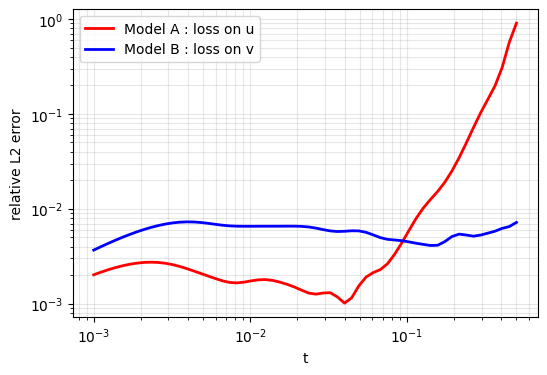

```python
t_curve = np.logspace(-3, np.log10(T), 60)
err_A = [relative_error(net_A, False, t) for t in t_curve]
err_B = [relative_error(net_B, True, t) for t in t_curve]

plt.figure(figsize = (6, 4))
plt.loglog(t_curve, err_A, 'r', linewidth = 2, label = 'Model A : loss on u')
plt.loglog(t_curve, err_B, 'b', linewidth = 2, label = 'Model B : loss on v')
plt.xlabel('t')
plt.ylabel('relative L2 error')
plt.legend()
plt.grid(True, which = 'both', alpha = 0.3)
plt.show()
```

The curves make the same point at a glance. The red curve is flat and low until $t \approx 0.1$ and then rises almost as a straight line on the logarithmic axes, heading for the level of no prediction at all. The blue curve is flat from beginning to end. The crossing of the two near $t = 0.1$ is where the solution has fallen to about a third of its initial size, which is where the weight $e^{-2\lambda t}$ has fallen to about one seventh.

The solution itself at two times, one while both modes are still present and one at the end of the interval, where the exact solution stands at $0.72\%$ of its initial height.

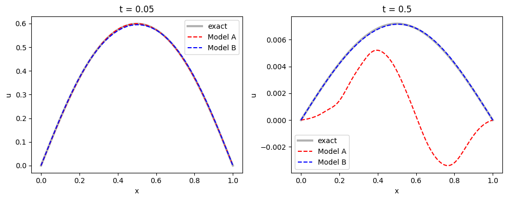

```python
plt.figure(figsize = (10, 4))

for j, t_value in enumerate([0.05, 0.5]):
    with torch.no_grad():
        t = t_value*torch.ones_like(x_plot)
        xs = x_plot.cpu().numpy().ravel()

        plt.subplot(1, 2, j + 1)
        plt.plot(xs, exact(x_plot, t).cpu().numpy().ravel(), 'k', linewidth = 3, alpha = 0.3)
        plt.plot(xs, solution(net_A, x_plot, t, False).cpu().numpy().ravel(), 'r--')
        plt.plot(xs, solution(net_B, x_plot, t, True).cpu().numpy().ravel(), 'b--')
        plt.legend(['exact', 'Model A', 'Model B'])
        plt.title(f't = {t_value}')
        plt.xlabel('x')
        plt.ylabel('u')

plt.tight_layout()
plt.show()
```

At $t = 0.05$ both models lie on top of the exact solution. At $t = 0.5$ the exact solution is a small hump, less than one percent of its initial height. Model B reproduces it. Model A returns a curve with a lower peak and a negative lobe over the right half of the interval, a shape the heat equation with these boundary conditions cannot produce. Its loss is nevertheless small, because at this time the residual of $u$ is multiplied by $e^{-2\lambda t}$, a factor of order $10^{-5}$, before it reaches the optimizer.

### 4.6.4. What the Lab Showed

Model A was accurate for the first tenth of the interval and nearly worthless at the end of it, and nothing about its training was wrong. The network had the capacity, the points were where they should be, and the loss went down steadily. What failed was the loss itself: a mean squared residual of $u$ is not a neutral measure of how well the equation is satisfied. It is a measure weighted by the size of the solution, and for a decaying transient that weighting spans orders of magnitude across the interval. The weighting is there whether or not anyone intends it.

Model B fixed the problem by dividing out the known decay, and it did so without tuning anything: no weight was chosen, no schedule introduced, no gradient measured. A function known before training began was moved from the network's job into the model, and the equation the network solves changed by one term. The price was small, a slightly larger error at the earliest times, where Model A had the advantage of concentrating all its effort.

This is the third time the notebook has made the same move: in the input, for a frequency (Section 3.3); in the output, for a singularity (Section 3.4); and here in time, for a decay. Whenever part of the solution is known in advance, take it out, and let the network represent only what is not known.

# Summary

**Key takeaways**

- A PINN puts the physics into the loss, but putting it there does not make the optimization easy, the sampling adequate, the representation suitable or the training order physical. Each of the limitations treated here, and the loss imbalance treated in **Regularization, MAP Estimation, and Loss Weighting**, is a way in which a correct loss can still be minimized to a wrong answer, and each remedy changes something other than the equation.
- **Sampling.** The loss is an average over the collocation points, so a region that holds few points holds little of the loss however large its residual. A collocation set should be graded like a mesh, dense where the solution is hard, and the same point budget redistributed in this way resolved the stress concentration of the Kirsch problem that a uniform grid missed.
- **Complex solution structures.** Spectral bias makes a network learn high frequencies last; a smooth bounded network cannot represent a singularity; a differentiable one cannot represent a kink. Fourier features change the input, enrichment adds a known singular function to the output, and domain decomposition gives each region its own network joined by interface conditions.
- **Causality in time.** A full-domain loss enforces the equation at late times before the early solution is right, and the optimizer settles on a zero-residual solution that the initial condition does not permit. Causal weighting lets later time slices count only after earlier ones have converged; time marching trains the interval window by window, each starting from the end state of the last.
- **Scale in time.** For a decaying solution the plain residual loss is exactly a weighted loss on the rescaled field, with weights $e^{-2\lambda t}$, so the end of the interval is unconstrained however the training is ordered. Dividing out the known decay, $u = e^{-\lambda t}v$, gives an equation for a field that does not decay, and the weighting disappears with it.

**Looking ahead.** Every method in this notebook makes one trained network solve one problem: one set of coefficients, one boundary and initial data, one geometry. Change any of them and the training starts again. **Deep Neural Operators** and **Fourier Neural Operator** learn the map from the data of a problem to its solution, so that a new instance costs a forward pass rather than a training run.